# Group B11 Vendex Challenge-2

Probability Models

# Libraries

Importing all the necessary libraries

```r
library(data.table)
library(readxl)
library(tidyverse)
library(janitor)
library(lubridate)
library(tidymodels)
library(GGally)
library(corrplot)
library(ROCR)
```

# Loading Data

**Please change the path according to your local directories**

```r
files <- list.files(path = '~/Desktop/R_Course/Assignments',
                    pattern = '.csv', full.names = TRUE)

machines <- read.csv(files[1])
failures <- read.csv(files[2])
products <- read.csv(files[3])
txns <- read.csv(files[4])
```

# Challenge Solution

## Question-1

We are merging the `txns` dataframe with `failures` and replacing the **NAs** in the aggregated dataframe with **0**.

```r
txns <- failures %>%
      select(timestamp, failure) %>%
      right_join(txns, by='timestamp') %>%
      mutate(failure = replace_na(failure, 0))
```

## Question-2

We are creating a new column called `last_vend` that contains the timestamp of the previous sale of each machine. We first sort the data by `machine` & `timestamp` and than we use the `shift` function and the important thing to note here is the fact that we need to perform a `group_by` on `machine` before shifting the data by 1 position.

```r
txns <- txns %>%
  arrange(machine, timestamp) %>%
  group_by(machine) %>%
  mutate(last_vend = shift(timestamp, n = 1, fill = NA))
```

## Question-3

We are creating a new column called `deltahours` containing, for every sale, the hours that passed since the last sale.

```r
txns <- txns %>%
      mutate(deltahours= as.numeric(difftime(timestamp, last_vend, units = "hours")))
```

## Question-4

We are creating a dataframe called `machine_daily_average` to calculate the average daily sales per machine.

```r
machine_daily_average<- txns %>%
                        group_by(machine, date) %>%
                        summarise(sales = n()) %>%
                        aggregate(sales ~ machine, FUN = mean) %>%
                        rename(daily_sales_machine = sales)
```

We are now merging the `txns` table with `machine_daily_average` by the `machine` column.

```r
txns <- txns %>%
        left_join(machine_daily_average, by='machine')
```

## Question-5

We are creating a new column in the `txns` table called `delta`. The interpretation of `delta` is the amount of **missed sales** if the machine didn’t break down (i.e. if it was selling at a constant rate).

```r
txns <- txns %>%
        mutate(delta = deltahours /(24/daily_sales_machine) )
```

## Question-6

### Creating the model

Before creating the logistic regression model, we first check for NAs.

```r
summary(txns)
```

```
  timestamp            failure            machine         date
 Length:1840500     Min.   :0.000000   Min.   :   1   Length:1840500
 Class :character   1st Qu.:0.000000   1st Qu.: 880   Class :character
 Mode  :character   Median :0.000000   Median :1472   Mode  :character
                    Mean   :0.008494   Mean   :1462
                    3rd Qu.:0.000000   3rd Qu.:2072
                    Max.   :1.000000   Max.   :2724

     column      product_name        last_vend           deltahours
 Min.   : 0.00   Length:1840500     Length:1840500     Min.   :   0.0000
 1st Qu.:13.00   Class :character   Class :character   1st Qu.:   0.0175
 Median :25.00   Mode  :character   Mode  :character   Median :   0.5933
 Mean   :27.03                                         Mean   :   2.8955
 3rd Qu.:39.00                                         3rd Qu.:   2.7642
 Max.   :69.00                                         Max.   :1576.1375
                                                       NA's   :2495
 daily_sales_machine     delta
 Min.   : 2.000      Min.   :  0.0000
 1st Qu.: 7.046      1st Qu.:  0.0086
 Median :10.333      Median :  0.2875
 Mean   :11.962      Mean   :  1.0452
 3rd Qu.:14.989      3rd Qu.:  1.1847
 Max.   :56.506      Max.   :610.0511
                     NA's   :2495
```

Lets drop all the rows where `delta` is NA. This in turn takes care of all the other rows.

```r
#Dropping rows where delta is NA
txns <- txns[complete.cases(txns$delta), ]
```

We removed **2495** rows which is **0.13%** of the total data.

The final step before building the model is to perform a train-test split. We perform a 70%-30% split stratified on `machine` column. Please find the code chunk below :

```r
set.seed(2022)
split <- initial_split(txns, strata = machine, prop = 0.7)
train <- training(split)
test <- testing(split)
```

We now create a logistic regression model and call it `m` . The target variable is `failure` and the independent variable is `delta` .

```r
m <- glm(formula = failure ~ delta, data = train, family = 'binomial')
```

Lets get the summary of the model

```r
summary(m)
```

```
Call:
glm(formula = failure ~ delta, family = "binomial", data = train)

Deviance Residuals:
    Min       1Q   Median       3Q      Max
-2.7299  -0.0858  -0.0696  -0.0653   3.5087

Coefficients:
             Estimate Std. Error z value Pr(>|z|)
(Intercept) -6.153402   0.017003  -361.9   <2e-16 ***
delta        0.481608   0.002604   184.9   <2e-16 ***
---
Signif. codes:  0 '***' 0.001 '**' 0.01 '*' 0.05 '.' 0.1 ' ' 1

(Dispersion parameter for binomial family taken to be 1)

    Null deviance: 125887  on 1286601  degrees of freedom
Residual deviance:  84832  on 1286600  degrees of freedom
AIC: 84836

Number of Fisher Scoring iterations: 8
```

We now find the **intercept** and **coefficient of delta** from the model.

```r
intercept = m$coefficients[1]
coefficient = m$coefficients[2]
```

### Part b

We now visualize the **sigmoid** function that we get as a result of building the model.

For this task, we first create a function called `lr` .

```r
lr <- function(x) 1/(1+exp(-(intercept + coefficient*x)))
```

We now plot the function in the range of [0,25] using the `curve()` function.

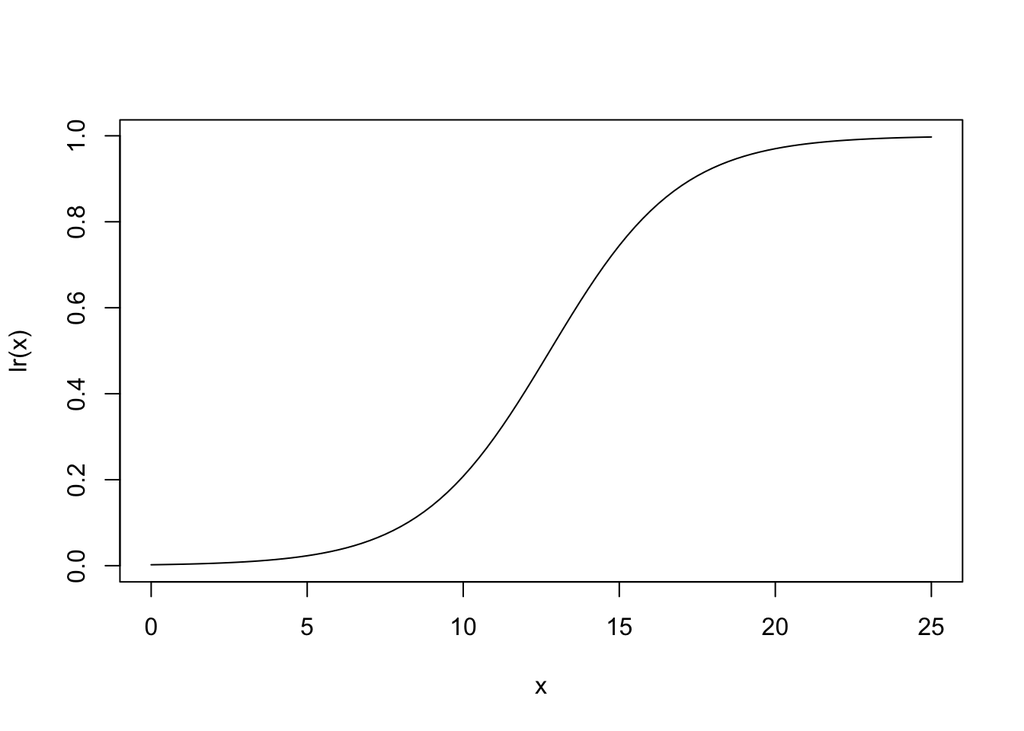

```r
curve(lr, from = 0, to = 25)
```

### Part c

There are two types of alarms :

- **Med-risk alarm** : The alarms that get fired when the probability of failure exceeds 60%.
- **High-risk alarm** : The alarms that get fired when the probability of failure exceeds 80%.

i) We find the threshold deltas for each type of alarm to fire.

For finding the thresholds, we create two functions for each type of alarm, which will be solved for getting the root.

```r
lr_med <- function(x) (1/(1+exp(-(intercept + coefficient*x))))-0.6
lr_high <- function(x) (1/(1+exp(-(intercept + coefficient*x))))-0.8
```

We leverage the `uniroot()` function for finding the roots of the above equations.

```r
med_threshold <- round(uniroot(lr_med, c(0,20))$root,2)
med_threshold
```

```
[1] 13.62
```

```r
high_threshold <- round(uniroot(lr_high, c(0,20))$root,2)
high_threshold
```

```
[1] 15.66
```

- The medium-risk threshold for delta is **13.62**
- The high-risk threshold for delta is **15.66**

ii) We find the average triggers per day for each threshold.

```r
avg_daily_med_alarms = nrow(txns %>% filter(delta > med_threshold)) / uniqueN(txns$date)
avg_daily_med_alarms
```

```
[1] 35.55556
```

```r
avg_daily_high_alarms = nrow(txns %>% filter(delta > high_threshold)) / uniqueN(txns$date)
avg_daily_high_alarms
```

```
[1] 23.74444
```

- Daily, on an average there are **36** medium risk alarms being fired.
- Daily, on an average there are **24** high risk alarms being fired.

iii) We calculate the percentage of false alarms among both the thresholds.

```r
total_med_alarms = nrow(txns %>% filter(delta > med_threshold))
total_med_false_alarms = nrow(txns %>% filter((delta > med_threshold) & (failure==0)))
percent_med_false_alarms = round(total_med_false_alarms/total_med_alarms*100,1)
percent_med_false_alarms
```

```
[1] 16
```

```r
total_high_alarms = nrow(txns %>% filter(delta > high_threshold))
total_high_false_alarms = nrow(txns %>% filter((delta > high_threshold) & (failure==0)))
percent_high_false_alarms = round(total_high_false_alarms/total_high_alarms*100,1)
percent_high_false_alarms
```

```
[1] 5.8
```

- **16%** of the medium risk alarms are false alarms.
- **5.8%** of the high risk alarms are false alarms.

### Part d

The first step is to calculate the current profit. The important step here is we project the current profit to an year.

```r
current_profit = nrow(txns)*1.7*(12/3)
```

**Case - 1** : If we only implemented medium risk alarms

```r
med_alarm <- txns %>% filter(delta > med_threshold)
med_alarm$threshold_hours <- med_threshold*(24/med_alarm$daily_sales_machine)
med_alarm$delta_fixed <- (med_alarm$threshold_hours+1.5)*(med_alarm$daily_sales_machine/24)
med_alarm$won_sales <- (med_alarm$delta - med_alarm$delta_fixed)*med_alarm$failure

added_revenue_med = sum(med_alarm$won_sales)*1.7*(12/3)
added_cost_med = uniqueN(txns$machine)*10*2.2
added_profit_med = added_revenue_med-added_cost_med

profit_uptick_med = (added_profit_med/current_profit)*100
profit_uptick_med
```

```
[1] 1.688557
```

```r
high_alarm <- txns %>% filter(delta > high_threshold)
high_alarm$threshold_hours <- high_threshold*(24/high_alarm$daily_sales_machine)
high_alarm$delta_fixed <- (high_alarm$threshold_hours+1.5)*(high_alarm$daily_sales_machine/24)
high_alarm$won_sales <- (high_alarm$delta - high_alarm$delta_fixed)*high_alarm$failure

added_revenue_high = sum(high_alarm$won_sales)*1.7*(12/3)
added_cost_high = uniqueN(txns$machine)*10*2.2
added_profit_high = added_revenue_high-added_cost_high

profit_uptick_high = (added_profit_high/current_profit)*100
profit_uptick_high
```

```
[1] 1.464363
```